# ASwEiF - pprojekt zaliczeniowy

Piotr Otręba

2026-01-13

# ASWEiF - projekt

## Część 1. Analiza spektralna na wybranych danych.

Dane do analizy pochodzą ze strony: https://ec.europa.eu/eurostat/databrowser/view/avia_paoc/default/table?lang=en&category=avia.avia_pa.avia_pao. Zawierają miesięczną liczbę pasażerów podróżujących z danego kraju (nas interesuje Polska) w transporcie lotniczym.

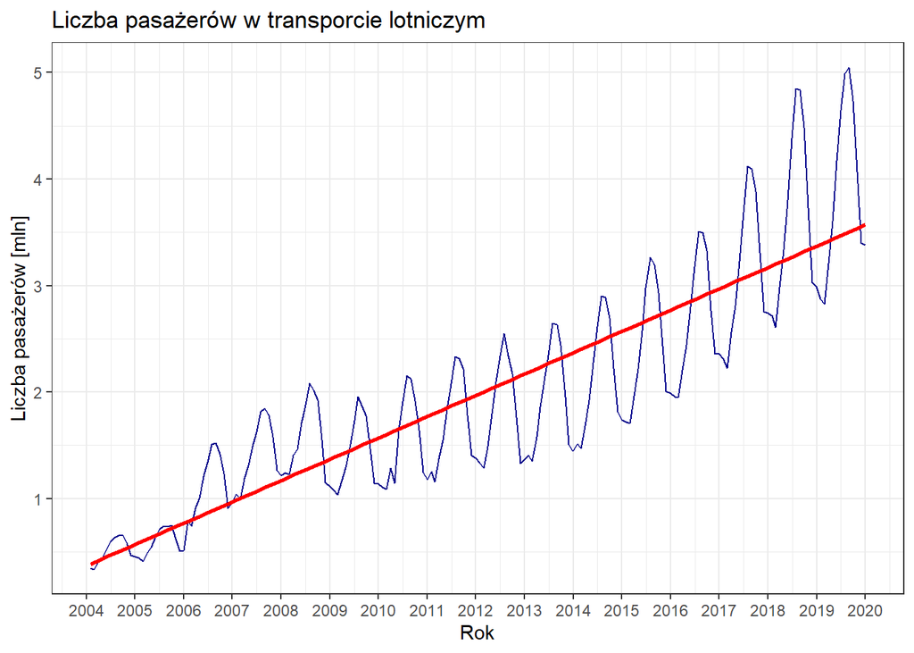

```r
dane <- read_excel("pl_pasazerowie2.xlsx") %>%
  mutate(data = as.Date(data))

ggplot(dane, aes(y = pasazerowie, x = data)) +
  geom_line(color = "darkblue") +
  theme_bw() +
  geom_smooth(method = "lm", color = "red", se = F) +
  scale_y_continuous(labels = function(x) x/1e6) +
  scale_x_date(date_breaks = "1 year", date_labels = "%Y") +
  labs(title = "Liczba pasażerów w transporcie lotniczym", x = "Rok", y = "Liczba pasażerów [mln]")
```

Dane wykazują trend wzrostowy. Widoczna jest też sezonowość - więcej pasażerów w okresie letnim. Dekompozycji szeregu czasowego dokonujemy, zakładając roczną sezonowość (`frequency = 12`) oraz multiplikatywny charakter wahań sezonowych (wzrost amplitudy w czasie).

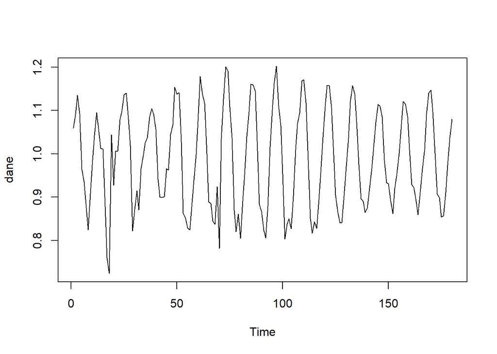

```r
dane_dekom<- decompose(ts(dane, frequency=12), type = "multiplicative")
dane <- as.ts(dane_dekom$random[7:(nrow(dane)-6), 2], frequency = 12)

# dane po usunięciu trendu i sezonowości
plot(dane, type = "l")
```

Powinniśmy otrzymać stacjonarny szereg czasowy. Wykres wydaje się potwierdzać stacjonarność, ale potwierdźmy ją testem ADF.

```r
adf.test(dane)
```

```
##
##  Augmented Dickey-Fuller Test
##
## data:  dane
## Dickey-Fuller = -11.924, Lag order = 5, p-value = 0.01
## alternative hypothesis: stationary
```

Otrzymane pvalue < 0.01 skłania do odrzucenia $H_0$ na rzecz $H_1$ mówiącej, że szereg jest stacjonarny.

### Analiza podstawowa.

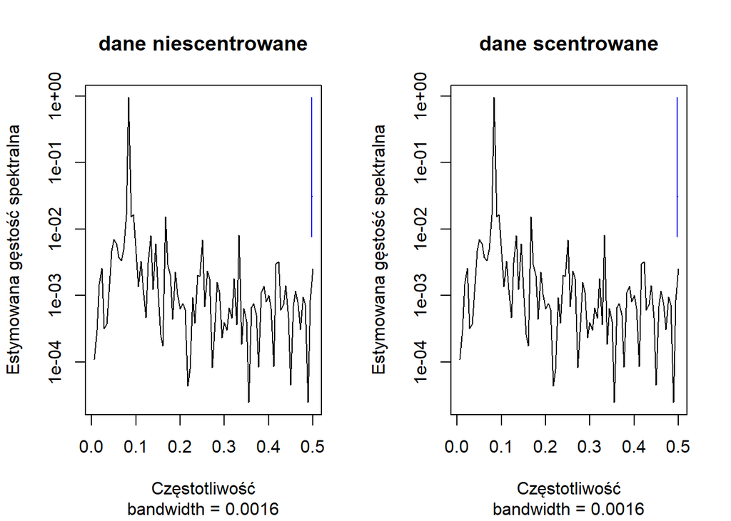

```r
pgram_niescentr <- spec.pgram(dane,log='no', taper=0,pad=0, plot = F,
                          fast=FALSE,demean=FALSE,detrend=FALSE)

dane_scentr <- dane - mean(dane)

pgram_scentr <- spec.pgram(dane_scentr,log='no', taper=0,pad=0, plot = F,
                          fast=FALSE,demean=FALSE,detrend=FALSE)

par(mfrow = c(1,2))
plot(pgram_niescentr, main = "dane niescentrowane",
     ylab= "Estymowana gęstość spektralna", xlab  = "Częstotliwość")
plot(pgram_scentr, main = "dane scentrowane",
     ylab= "Estymowana gęstość spektralna", xlab  = "Częstotliwość")
```

Periodogram dla danych scentrowanych nie różni się od tego dla danych niescentrowanych. Centrowanie polega na usunięciu średniej, która odpowiada za częstotliwość $f=0$. Jeżeliby nasze dane miały bardzo wysoki pik dla $f=0$, trudniej byłoby zobaczyć na periodogramie piki sezonowe. To jednak nie ma miejsca i centrowanie niewiele zmienia.

```r
czestotliwosc <- pgram_scentr$freq[which.max(pgram_scentr$spec)]
sezonowosc <- 1/czestotliwosc
cat(paste0("Periodogram wskazuje na dominację częstotliwości: ",
    round(czestotliwosc, 3), ", która odpowiada cyklowi ", sezonowosc, "-miesięcznemu."))
```

```
## Periodogram wskazuje na dominację częstotliwości: 0.083, która odpowiada cyklowi 12-miesięcznemu.
```

Aby przeanalizować wpływ liczby obserwacji $N$ niebędącej wielokrotnością okresu $m=12$, wyrysujemy periodogram przyjmując $N'=177$.

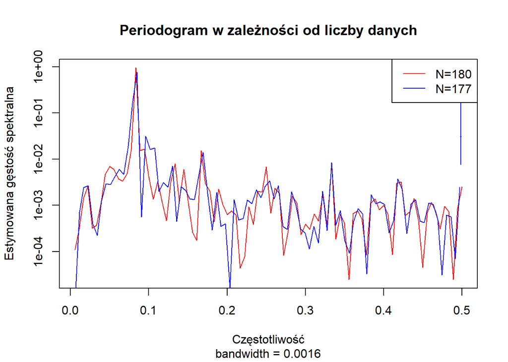

```r
pgram_177 <- spec.pgram(dane_scentr[1:177],
                        log='no',
                        taper=0,pad=0, plot = F,
                        fast=FALSE,demean=F,
                        detrend=FALSE)

plot(pgram_scentr, main = "Periodogram w zależności od liczby danych",
     ylab= "Estymowana gęstość spektralna",
     xlab  = "Częstotliwość", col = "red")
lines(pgram_177$freq, pgram_177$spec, type = "l", col = "blue",
     ylab= "Estymowana gęstość spektralna",
     xlab  = "Częstotliwość")
legend("topright", legend = c("N=180", "N=177"),
       col= c("red", "blue"), lty=1)
```

Gdy $N$ nie jest podzielne przez 12, piki na wykresie są przesunięte względem oryginalnego periodogramu. Celem tworzenia periodogramu jest zidentyfikowanie częstotliwości sezonowej $f^*=\frac{1}{m}$, gdzie $m$ to okres. Jeżeli jednak przyjmiemy $N'$ niepodzielne przez $m$, to wyliczymy wartości DFT danej wzorem: $X_k = \sum_{t=0}^{n-1}{x_te^{-2\pi ikt}}$ nie dla wartości $k^*$ równej dokładnie $\frac{N}{p}$, lecz dla wartości bliskich temu ułamkowi liczb całkowitych. To powoduje przesunięcie periodogramu.

### Porównanie metod.

Wyznaczamy periodogram z definicji. Aby obliczyć 95% PU, korzystamy z faktu, że $\frac{2I(\omega)}{f(\omega)} \sim \chi^2_{2}$, gdzie $f(\omega)$ to nieznane widmo gęstości spektralnej.

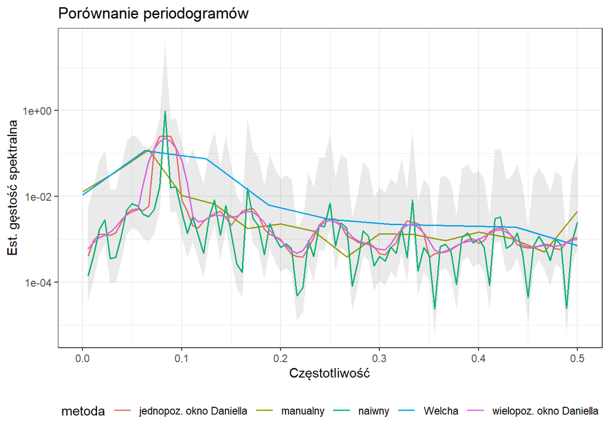

```r
# periodogram naiwny
naiwny <- spec.pgram(dane_scentr, taper=0, demean = F,
                     pad=0, plot = F)
freq <- naiwny$freq

# 95 % PU
dolny <- 2*naiwny$spec/qchisq(0.025, 2)
gorny <- 2*naiwny$spec/qchisq(0.975, 2)

# okno jednowymiarowe Daniella
daniell_jedn <- spec.pgram(dane_scentr, taper=0, demean = F,pad=0, plot = F, spans = 5)

# okno wielowymiarowe Daniella
daniell_wiel <- spec.pgram(dane_scentr, taper=0, demean = F,
                     pad=0, plot = F, spans = c(5,5))

# Periodogram Welcha
welch <- pwelch(as.vector(dane_scentr))

# wyliczenie periodogramów dla 6 okresów
wektor <-  c(1, seq(from = length(dane_scentr)/6, to = length(dane_scentr), by = length(dane_scentr)/6))
manualny <- rowMeans(data.frame(do.call(cbind, lapply(2:length(wektor), function(i){
  spec.pgram(dane_scentr[wektor[i-1]:wektor[i]], taper=0, demean = F,
                     pad=0, plot = F)$spec
} ))))
manualny.freq <- seq(0, 0.5, length.out = length(manualny))

# łączę wyniki
wyniki <- data.frame(
  metoda = c(rep(
    c("naiwny",
      "jednopoz. okno Daniella",
      "wielopoz. okno Daniella"),
    each = length(naiwny$freq)),
    rep("Welcha", length(welch$freq)), rep("manualny", length(manualny))),
  freq = c(rep(naiwny$freq, times = 3), welch$freq, manualny.freq),
  spektrum = c(
    naiwny$spec,
    daniell_jedn$spec,
    daniell_wiel$spec,
    welch$spec,
    manualny))

# przedziały ufności
pu <- data.frame(
  freq = naiwny$freq,
  dolny = dolny,
  gorny = gorny)

ggplot(wyniki, aes(x = freq, y = spektrum, color = metoda)) +
  geom_line(linewidth = 0.7) +
  geom_ribbon(
    data = pu,
    aes(x = freq, ymin = dolny, ymax = gorny),
    inherit.aes = FALSE,
    alpha = 0.1
  ) +
  scale_y_log10() +
  theme_bw() +
  labs(title = "Porównanie periodogramów",
       y  = "Est. gęstość spektralna", x = "Częstotliwość") +
  theme(legend.position = "bottom")
```

Największą wariancję ma periodogram naiwny. Metoda Welcha, polegająca na uśrednianiu periodogramów z częściowo nakładających się na siebie okien czasowych, podobnie jak jednopoziomowe i wielopoziomowe wygładzanie oknem Daniella powodują redukcję wariancji. Periodogram manualny, liczony na zasadzie uśredniania periodogramów z rozłącznych podokresów, a tym bardziej periodogram Welcha, pokazują zbyt wysoką gęstość spektrum w obszarze b. niskiej częstotliwości. Pytanie o to, która metoda jest najlepsza, sprowadza się do kompromisu bias-variance. Patrząc na ten rysunek, skłaniałbym się ku jednemu z wariantów wygładzania oknem Daniella, ponieważ ma on stosunkowo niską wariancję, a jednocześnie jednoznacznie wskazuje sezonową (roczną) częstotliwość.

### Analiza niekompletnych danych

W tej sekcji zbadamy zachowanie periodogramu naiwnego oraz periodogramu Lomba-Scargle’a w obecności braków danych. W tym celu usuniemy 30% obserwacji.

```r
set.seed(1)
n <- length(dane)
t <- 1:n  # Indeksy czasowe

# Losowe usunięcie 30% obserwacji
indeksy_brakow <- sample(1:n, size = floor(0.3 * n))
dane_z_lukami <- dane
dane_z_lukami[indeksy_brakow] <- NA

t_ls <- t[-indeksy_brakow]
y_ls <- dane_z_lukami[-indeksy_brakow]

ls_result <- lsp(y_ls, times = t_ls, alpha = 0.05,
                 main = "Periodogram Lomba-Scargle'a",
                 xlab = "Częstotliwość", ylab = "Spektrum")
```

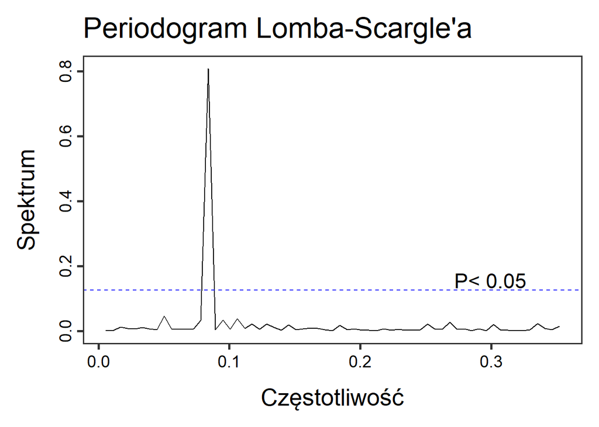

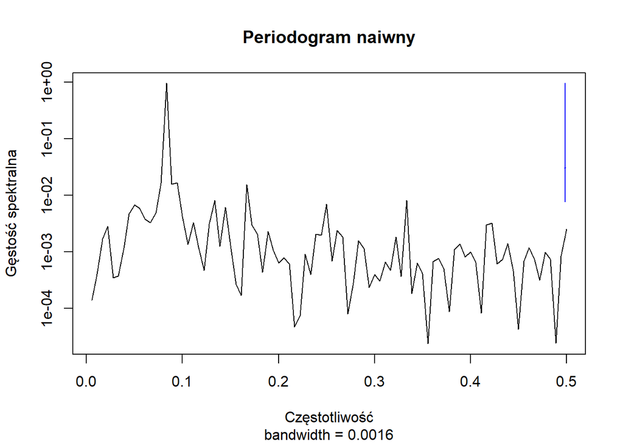

```r
spec.pgram(dane, pad=0, taper=0,
           main = "Periodogram naiwny",
           xlab = "Częstotliwość", ylab = "Gęstość spektralna")
```

```r
cat("Periodogram LS wykrywa częstotliwość okresową równą:", ls_result$peak.at[1], ", która odpowiada okresowi około", round(1/ls_result$peak.at[1]), "m-cy \np-value:", ls_result$p.value)
```

```
## Periodogram LS wykrywa częstotliwość okresową równą: 0.08379888 , która odpowiada okresowi około 12 m-cy
## p-value: 8.158625e-45
```

Zatem periodogram Lombe’a Scargle’a potwierdza przypuszczenie o cyklu rocznym w danych dot. liczby pasażerów w transporcie lotniczym.

## Część 2. Portfolio zadań.

### Zadanie 1.3

Stosujemy test Chochrane’a w celu wykrycia, czy któraś ze stacji pomiarowych cechuje się odstającą od pozostałych stacji wariancją pomiarów stanu wody.

```r
library(outliers)
dane <- read.csv("Dane/poziom_wody_wiele.csv", sep=";")
dane_long <- pivot_longer(dane, cols=names(dane), names_to = "grupa", values_to = "poziom_wody")

cochran.test(poziom_wody ~ grupa, dane_long)
```

```
##
##  Cochran test for outlying variance
##
## data:  poziom_wody ~ grupa
## C = 0.91105, df = 51, k = 3, p-value < 2.2e-16
## alternative hypothesis: Group X69.87 has outlying variance
## sample estimates:
##       X63.04       X69.87       X81.45
## 0.0014383529 0.0219770196 0.0007072941
```

Statystykę w teście Cochrane’a wyliczamy ze wzoru: $C_j = \frac{S_j^2}{\sum_{i=1}^{N} S_i^2}$. p-value wskazuje, że pomiary dokonywane na stacji X69.87 mają wariancję odstającą (w tym przypadku: istotnie większą) w stosunku do wariancji pomiarów na pozostałych 2 stacjach.

### Zadanie 1.5

Wygładzamy szereg czasowy PKB za pomocą średnich ruchomych różnych rzędów.

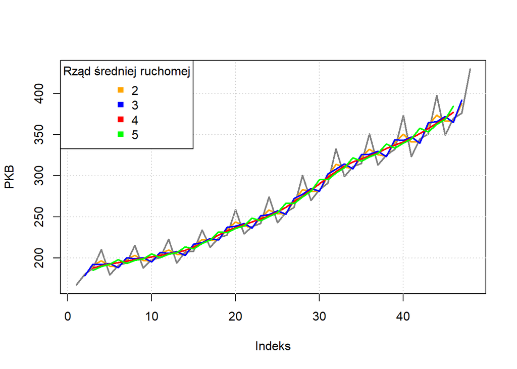

```r
x <- read.table("Dane/pkb.csv", sep=";", header = TRUE)
x <- x[,1]

# dane niewygładzone
plot(x, type="l", col=grey(.5), lwd=2, ylab = "PKB", xlab = "Indeks")
grid()

# wygładzamy średnią ruchomą z użyciem funkcji filter
# najpierw rząd=2
f2 <- c(1/4, 0.5, 1/4)
x_2 <- stats::filter(x, f2, sides=2)
lines(x_2, col="orange", lwd=2)

# rząd=3
f3 <- c(1/3, 1/3, 1/3)
x_3 <- stats::filter(x, f3, sides=2)
lines(x_3, col="blue", lwd=2)

# rząd=4
f4 <- c(1/8, 1/4, 1/4, 1/4, 1/8)
x_4 <- stats::filter(x, f4, sides=2)
lines(x_4, col="red", lwd=2)

# rząd=5
f5 <- c(1/5, 1/5, 1/5, 1/5, 1/5)
x_5 <- stats::filter(x, f5, sides=2)
lines(x_5, col="green", lwd=2)

legend("topleft", legend = c("2", "3", "4", "5"),
       col = c("orange", "blue", "red", "green"),
       pch = 15,
       title = "Rząd średniej ruchomej")
```

Widzimy, że czerwona linia, odpowiadająca średniej ruchomej rzędu 4, skutecznie wygładza szereg czasowy. Dla średnich ruchomych mniejszych rzędów widoczna jest jeszcze okresowość, podobnie jak dla średniej rzędu 5. Stąd rząd okresowości danych wynosi 4.

### Zadanie 1.8

Generujemy 200 wartości funkcji:
$$y_t =
cos(2\pi tf_1 + \frac{\pi}{5} + 3sin(2\pi tf_2) - 2sin(2\pi tf_1) +
sin(2\pi tf_3) + X_t$$
, gdzie:
$$f_1 =
10Hz, f_2 = 5 Hz, f_3 = 15Hz$$
$$X_t
\sim N(0, 0.1)$$

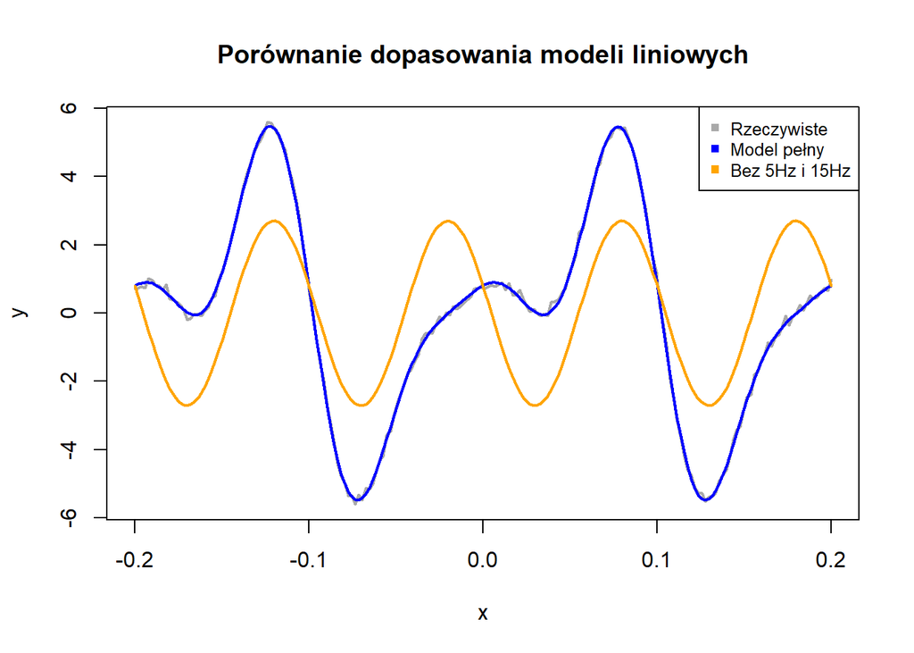

```r
x <- seq(-0.2, 0.2, length.out = 200)

# Generowanie wartości y zgodnie ze wzorem
y <- cos(2*pi*10*x + pi/5) + 3*sin(2*pi*5*x) -
     2*sin(2*pi*10*x) + sin(2*pi*15*x) + rnorm(length(x), sd=0.1)

# Konwersja na macierze i ramkę danych
dat <- data.frame(x = x, y = y)

# Dopasowanie pełnego modelu regresji liniowej
mod <- lm(y ~ cos(2*pi*10*x + pi/5) +
          sin(2*pi*5*x) + sin(2*pi*10*x) + sin(2*pi*15*x), data = dat)

# Model okrojony (bez 5Hz i 15Hz)
mod1 <- lm(y ~ cos(2*pi*10*x + pi/5) + sin(2*pi*10*x), data = dat)

# Przygotowanie danych do wykresu
res <- data.frame(rzeczywiste = y, d_pelny = fitted(mod), d_okrojony = fitted(mod1))
res$x <- x

plot(res$x, res$rzeczywiste, col = "darkgray", type = "l", lwd=2,
     xlab = "x", ylab = "y", main = "Porównanie dopasowania modeli liniowych")
lines(res$x, res$d_pelny, col = "blue", lwd=2)
lines(res$x, res$d_okrojony, col = "orange", lwd=2)
legend("topright", col = c("darkgray", "blue", "orange", lwd=2),
       legend = c("Rzeczywiste", "Model pełny", "Bez 5Hz i 15Hz"), pch=15, cex=.8)
```

Model pełny, ten uwzgledniający wszystkie 3 częstotliwości, znacznie lepiej pasuje do danych w porównaniu do modelu uwzględniającego tylko częstotliwość 10 Hz.

```r
cat("R2 dla pełnego modelu wynosi:", summary(mod)$adj.r.squared,
    "\na dla modelu okrojonego:", summary(mod1)$adj.r.squared)
```

```
## R2 dla pełnego modelu wynosi: 0.9989276
## a dla modelu okrojonego: 0.4168694
```

Potwierdzają to także współczynniki determinacji obu modeli.

### Zadanie 2.5

Wczytujemy dane i centrujemy szeregi czasowe. Porównujemy periodogram dla danych zawierających trend z tym dla danych, które są go pozbawione.

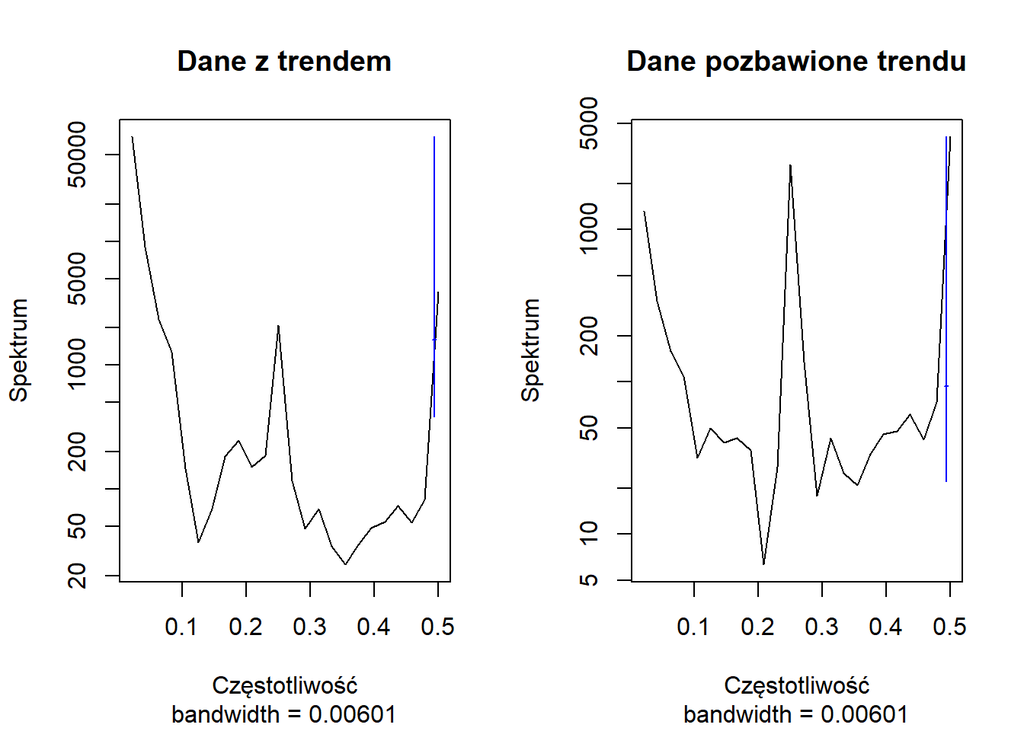

```r
dane <- read.csv("Dane/pkb.csv", sep =";")

dane$PKB <- dane$PKB - mean(dane$PKB)
dane$PKB_detrended <- dane$PKB_detrended - mean(dane$PKB_detrended)

# periodogram naiwny dla całych danych
par(mfrow = c(1,2))
spec.pgram(dane$PKB, main = "Dane z trendem", demean = F,
           detrend = F, xlab = "Częstotliwość", ylab = "Spektrum")
spec.pgram(dane$PKB_detrended, main = "Dane pozbawione trendu", demean = F,
           detrend = F, xlab = "Częstotliwość", ylab = "Spektrum")
```

Widzimy, że periodogram sporządzony dla danych stacjonarnych, pozbawionych trendu, znacznie wyraźniej pokazał pik dla częstotliwości 0.25 Hz. Z tego periodogramu możemy odczytać okresowość danych wynoszącą 4 (zatem najwyraźniej są to dane kwartalne).

Powtarzamy badanie dla odpowiednio 45 (liczba niepodzielna przez rząd okresowości danych) i 44 obserwacji (podzielna przez rząd okresowości).

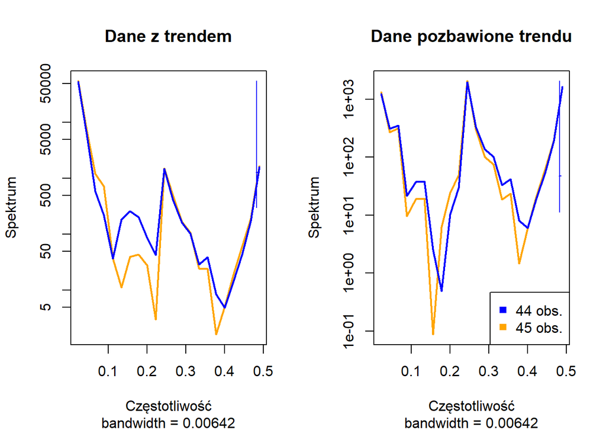

```r
# periodogram naiwny - dane z trendem
par(mfrow = c(1,2))
spec.pgram(dane[1:45,]$PKB, main = "Dane z trendem", demean = F,
           detrend = F, xlab = "Częstotliwość", ylab = "Spektrum", col = "orange", lwd=2)

spec.pgram(dane[1:44,]$PKB, main = "Dane z trendem", demean = F,
           detrend = F, xlab = "Częstotliwość", ylab = "Spektrum", add = T, col = "blue",  lwd=2)

# periodogram - dane bez trendu.
spec.pgram(dane[1:45,]$PKB_detrended, main = "Dane pozbawione trendu", demean = F,
           detrend = F, xlab = "Częstotliwość", ylab = "Spektrum", col = "orange",  lwd=2)
spec.pgram(dane[1:44,]$PKB_detrended, main = "Dane pozbawione trendu", demean = T,
           detrend = F, xlab = "Częstotliwość", ylab = "Spektrum", add=T, col = "blue",  lwd=2)

legend("bottomright", legend = c("44 obs.", "45 obs."), col = c("blue", "orange"), pch=15)
```

Obserwujemy zjawisko analogiczne do tego, które zachodziło w Części 1 projektu. Gdy $n$ nie jest podzielne przez rząd okresowości, nie wyilczamy DFT dla częstotliwości równej dokładnie częstotliwości okresowej. Stąd nieznaczne przesunięcie periodogramów względem siebie.

### Zadanie 2.8

Niech $y_t = cos(2\pi ft) + x(t); f=200Hz$. Ponadto, $x(t) \sim N(0,1)$. Wyznaczamy periodogram dla szeregu czasowego $y_t$ - odpowiednio naiwny, wygładzony oknem Daniella (testujemy różne szerokości okna) i wygładzony metodą Welcha. Dla metody Welcha przetestujemy ponadto różne wartości parametru `overlap` odpowiadającego za to, jak bardzo nakładają się naa siebie okna.

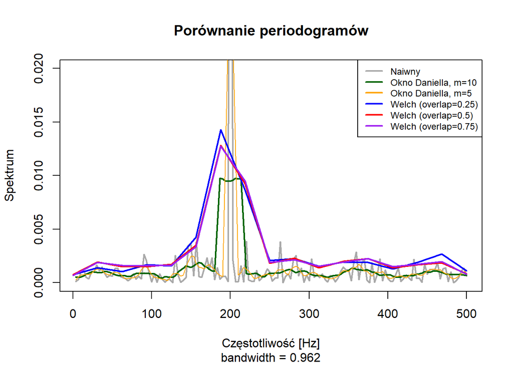

```r
t <- (0:296)/1000
f <- 200
set.seed(200)
y <- cos(2*pi*f*t) + rnorm(n=length(t))
y <- y- mean(y)

y_ts <- ts(y, frequency = 1000)

welch_75 <- pwelch(as.numeric(y_ts), fs=1000, overlap = 0.75)
welch_50 <- pwelch(as.numeric(y_ts), fs=1000, overlap = 0.5)
welch_25 <- pwelch(as.numeric(y_ts), fs=1000, overlap = 0.25)

par(mfrow =c(1,1))
spec.pgram(y_ts, taper=0, pad=0, detrend=F,
           main = "Porównanie periodogramów",
           col = "darkgray", ylab = "Spektrum", ylim = c(0, .02),
           xlab="Częstotliwość [Hz]", lwd=2, log="no")

spec.pgram(y_ts, taper=0, pad=0, detrend=F, add=TRUE,
           col = "darkgreen", spans = 10, log="no", lwd=2)

spec.pgram(y_ts, taper=0, pad=0, detrend=F, add=TRUE,
           col = "orange", spans = 5, log="no")
lines(welch_25$freq, welch_25$spec, col = "blue", lwd=2)
lines(welch_50$freq, welch_50$spec, col = "red", lwd=2)
lines(welch_75$freq, welch_75$spec, col = "purple", lwd=2)

legend("topright", legend = c("Naiwny", "Okno Daniella, m=10", "Okno Daniella, m=5",
                              "Welch (overlap=0.25)",
                              "Welch (overlap=0.5)", "Welch (overlap=0.75)"),
       col = c("darkgray", "darkgreen", "orange", "blue", "red", "purple"),
       lty=1, lwd=2, cex = .75)
```

Wszystkie metody prowadzą do jednoznacznego wskazania częstotliwości $f=200Hz$ jako częstotliwości okresowej. Najmniejszą wariancję wydaje się mieć periodogram wygładzony oknem Daniella o szer. 10. Dla metody Welcha, niezależnie od wartości parametru `overlap`, częstotliwość okresowa jest dobrze wyłapywana.

### Zadanie 2.10

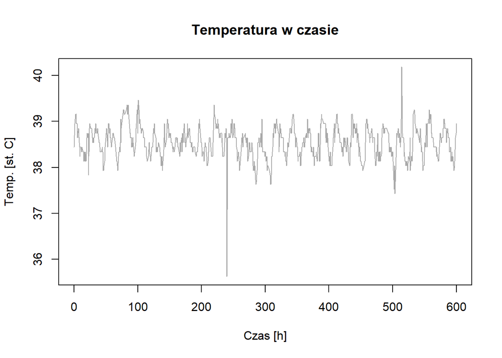

```r
library(lomb)
dane <- read.delim("Dane/ibex.csv", sep = " ")
plot(dane$hours, dane$temp, type = "l", col = "darkgray" ,
     main = "Temperatura w czasie", xlab = "Czas [h]", ylab = "Temp. [st. C]")
```

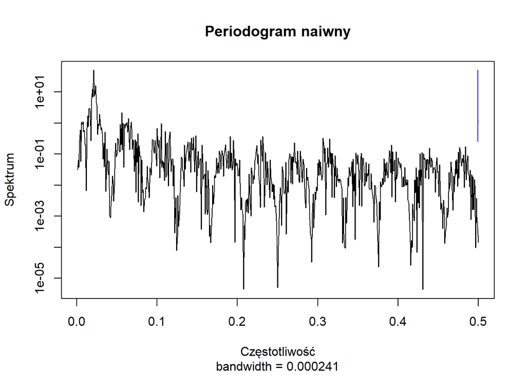

```r
temp <- diff(dane$temp, lag = 24)
spec.pgram(temp, pad=0, demean = T, detrend = F,
           main = "Periodogram naiwny", cex = .5,
           xlab = "Częstotliwość", ylab = "Spektrum")
```

```r
lomb <- lsp(temp, main = "Periodogram Lombe'a Scargle'a",
            alpha = .05, cex = .5, ylab = "Spektrum", xlab = "Częstotliwość")
```

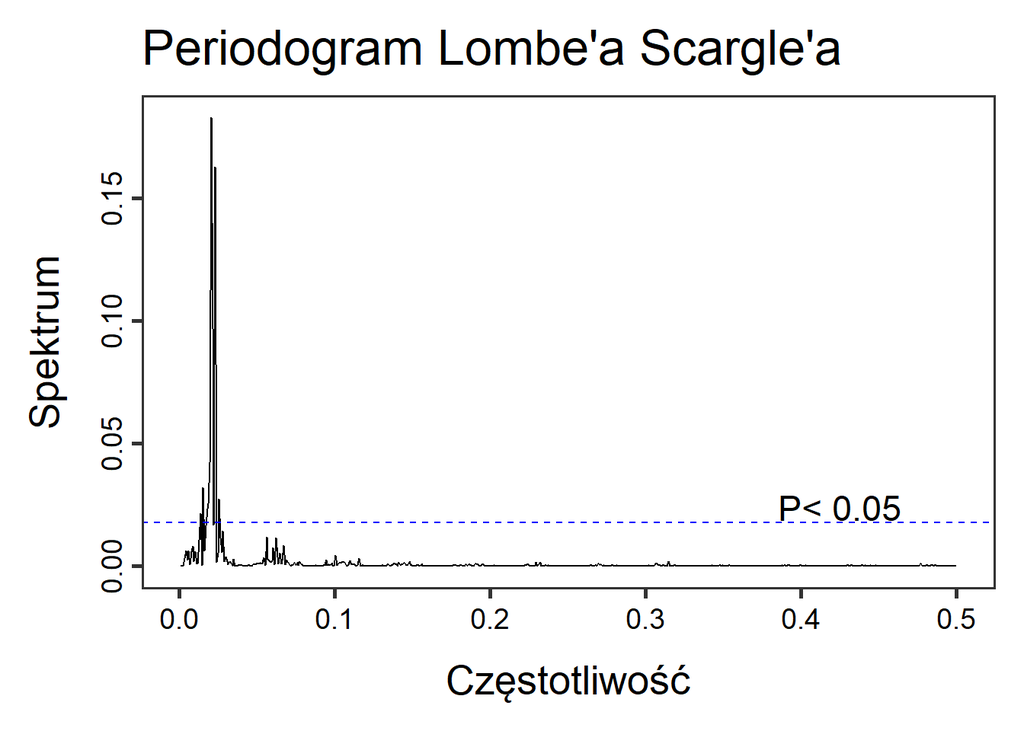

W tych danych mamy do czynienia z nierównomiernym próbkowaniem (pomiar nie jest dokonywany w odstępie na przykład 1h, tylko z nieregularnymi odstępami). Ponadto, sygnał nie jest tutaj bardzo mocny. W takich sytuacjach można, w celu znalezienia częstotliwości okresowych, zastosować periodogram Lombe’a Scargle’a. Pozwala on ocenić istotność statystyczną słabych sygnałów przy nierównomiernym próbkowaniu. Pik na tym periodogramie jest wyraźny i mocno wykracza poza linię wyznaczającą poziom istotności $\alpha=5\%$.

```r
cat("Częstotliwość okresowa to:", lomb$peak.at[1], "co odpowiada okresowi:", 1/lomb$peak.at[1], "h.")
```

```
## Częstotliwość okresowa to: 0.02040816 co odpowiada okresowi: 49 h.
```

W danych mamy zatem do czynienia z okresem około 2-dniowym.

### Zadanie 3.8

Generujemy szereg czasowy i dopasowujemy do niego model ARFIMA oraz model ARIMA.

```r
library(fracdiff)
library(forecast)

set.seed(123)
# generujemy szereg czasowy
x <- fracdiff.sim(n=1000, ar=.1, d=.4, ma=-.4)$series

# dopasowujemy model arfima
arfima.fit <- arfima(x)

summary(arfima.fit)
```

```
##
## Call:
##   arfima(y = x)
##
## Coefficients:
##        Estimate Std. Error z value Pr(>|z|)
## d       0.34273    0.01011  33.900  < 2e-16 ***
## ar.ar1  0.13063    0.06595   1.981   0.0476 *
## ma.ma1 -0.39643    0.05970  -6.640 3.14e-11 ***
## ---
## Signif. codes:  0 '***' 0.001 '**' 0.01 '*' 0.05 '.' 0.1 ' ' 1
## sigma[eps] = 0.9907923
## [d.tol = 0.0001221, M = 100, h = 1.487e-05]
## Log likelihood: -1410 ==> AIC = 2828.29 [4 deg.freedom]
```

```r
arima.fit <- auto.arima(x)
```

Zarówno komponent autoregresyjny, jak i komponent średniej ruchomej są w modelu ARFIMA istotne statystycznie na poziomie istotności 5%. Wyświetlamy reszty modelu ARFIMA.

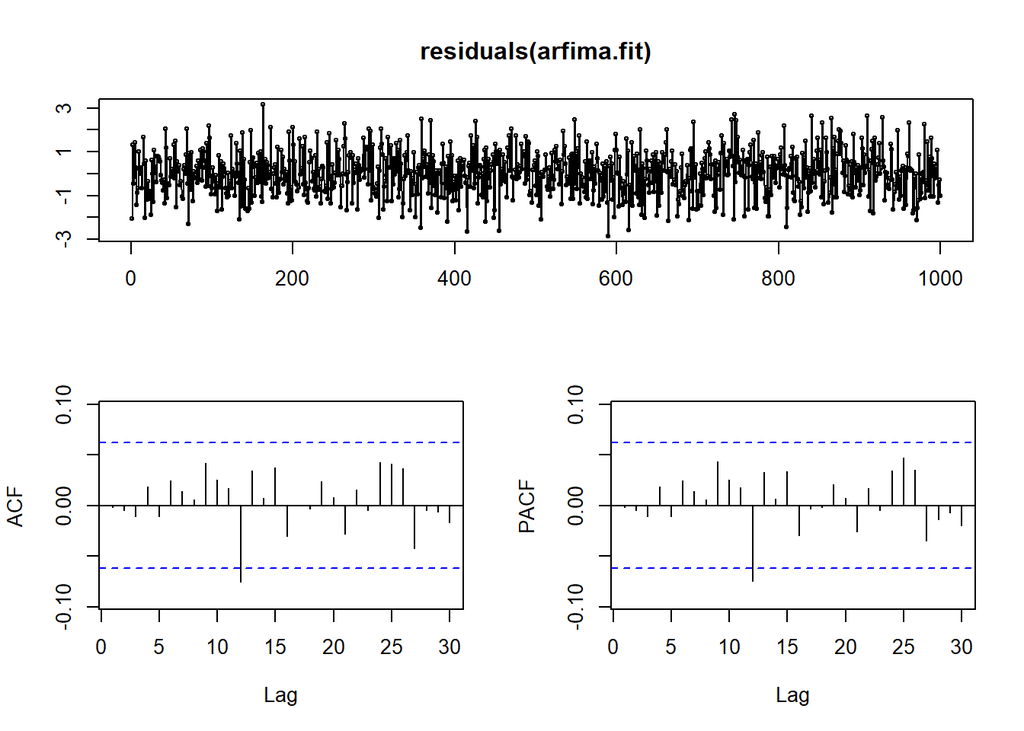

```r
tsdisplay(residuals(arfima.fit))
```

Wykresy ACF i PACF nie wykazują występowania autokorelacji reszt - to dobrze. Również nie wydaje się, aby wariancja reszt zmieniała się w czasie.

Wykonujemy prognozę na 100 obserwacji do przodu dla obu modeli - ARFIMA i ARIMA.

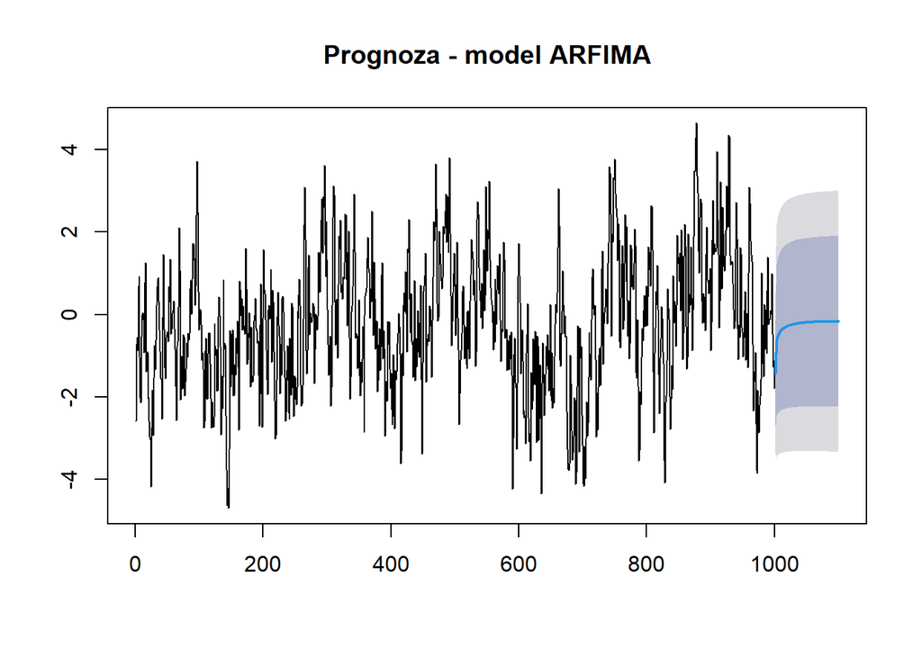

```r
plot(forecast(arfima.fit, h=100), main = "Prognoza - model ARFIMA")
```

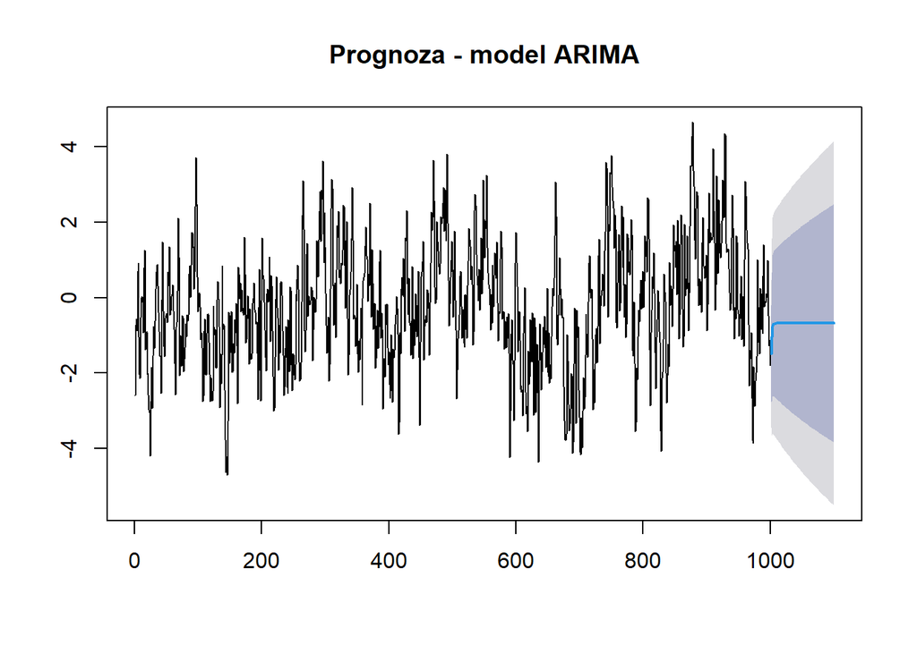

```r
plot(forecast(arima.fit, h=100), main = "Prognoza - model ARIMA")
```

Widzimy, że dla ziarna 123 prognoza modelu ARIMA jest mniej dokładna (szerszy przedział ufności). Zatem cząstkowe różnicowanie, stosowane w modelu ARFIMA, poprawia jakość tej prognozy. Testowałem, jak te prognozy wyglądają dla różnych ziaren i powyższy wniosek nie jest ogólny, czasem PU dla ARIMY nie jest węższy.

### Zadanie 3.12

Wyznaczamy periodogram naiwny dla scentrowanego szeregu czasowego oraz dla składowej cyklicznej szeregu uzyskanej po zastosowaniu filtru Christiano-Fitzgeralda i Hodricka-Prescotta.

W filtrze CF określamy dwa parametry, $p_l$ i $p_u$, które wspólnie określają interesujące nas pasmo. Z dokumentacji funkcji `cffilter` wynika, że filtr przepuszcza pasmo częstotliwości $(a, b) \cup (-a, -b)$, gdzie $a = \frac{2\pi}{p_u}$, $b = \frac{2\pi}{p_l}$. Zdefiniujemy filtr CF w dwóch wariantach, w pierwszym $p_l=3, p_u=6$, w drugim $p_l=6, p_u=24$. A zatem pierwszy filtr będzie wyłapywał krótkie, a drugi długie cykle.

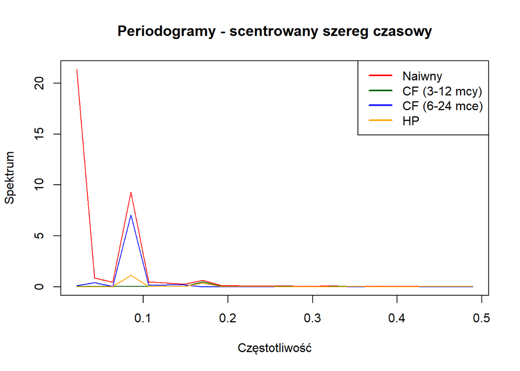

```r
library(mFilter)
dane_ts <- read.delim("Dane/infl_bezr.csv", sep=";")[2] %>% as.ts(frequency = 12)

# centrowanie
dane_ts <- dane_ts - mean(dane_ts)


cf_short <- spec.pgram(cffilter(dane_ts, pl=3, pu=6)$cycle,
           detrend = F, pad=0, taper=0, demean = F, fast = F, plot=F)
cf_long <- spec.pgram(cffilter(dane_ts, pl=6, pu=24)$cycle,
           detrend = F, pad=0, taper=0, demean = F, fast = F, plot=F)

hp <- spec.pgram(hpfilter(dane_ts, freq = 12,
        type="frequency")$cycle, detrend = F,
        pad=0, taper=0, demean = F, fast = F, plot=F)

oryg <- spec.pgram(dane_ts, detrend = F,
                   pad=0, taper=0,
                   demean = F, fast = F, plot = F)

plot(oryg$freq, oryg$spec, col = "red", type = "l",
     main = "Periodogramy - scentrowany szereg czasowy",
     ylab = "Spektrum", xlab = "Częstotliwość")
lines(cf_short$freq, cf_short$spec, col = "darkgreen")
lines(cf_long$freq, cf_long$spec, col = "blue")
lines(hp$freq, hp$spec, col = "orange")
legend("topright",
       legend = c("Naiwny", "CF (3-12 mcy)", "CF (6-24 mce)", "HP"),
       col = c("red", "darkgreen", "blue", "orange"),
       lty = 1, lwd = 2)
```

Po pierwsze, zauważąmy, że filtr Hodricka-Prescotta blokuje niskie częstotliwości. Jest to szczególnie widoczne dla zakresu 0-0,05. To spodziewane zachowanie - filtr HP wycina trend. Po drugie, filtr CF “zorientowany” na dłuższe cykle (kolor niebieski) pokazuje wyraźny pik, tzn. przepuszcza częstotliwość odpowiadającą (na oko) rocznemu cyklowi (około $1/0.08\approx12$). Po trzecie, filtr CF, który ma wyłapywać ewentualne krótkie cykle, trwające mniej niż rok, nie wskazuje na ich występowanie w naszych danych.

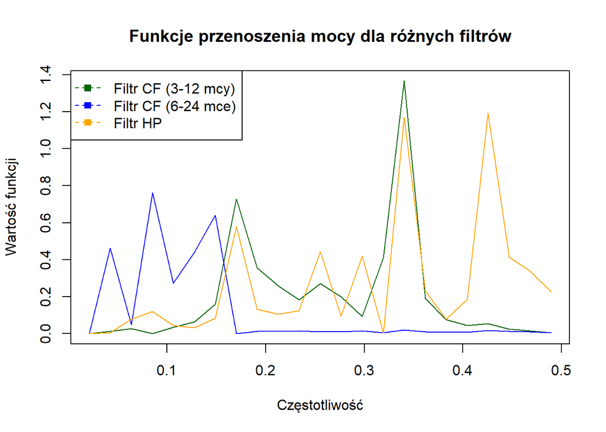

```r
# wyznaczamy funkcję przenoszenia mocy
transfer_fun <- function(pgram_oryg, pgram2) {pgram2$spec / pgram_oryg$spec}
plot(oryg$freq, transfer_fun(oryg, cf_short), type = "l", col  ="darkgreen",
     main = "Funkcje przenoszenia mocy dla różnych filtrów",
     ylab = "Wartość funkcji", xlab = "Częstotliwość")
lines(oryg$freq, transfer_fun(oryg, cf_long), col = "blue")
lines(oryg$freq, transfer_fun(oryg, hp), col = "orange")
legend("topleft", c("Filtr CF (3-12 mcy)", "Filtr CF (6-24 mce)", "Filtr HP"),
       col = c("darkgreen", "blue", "orange"), lty=2, pch=15)
```

Interesująca jest funkcja przenoszenia mocy dla niebieskiego filtra CF. Praktycznie nie przepuszcza on częstotliwości większych niż $\approx 0,16 Hz$, co odpowiada cyklom półrocznym. Ten fakt można powiązać z doborem parametru $p_l=6$. Potwierdza się też obserwacja z poprzedniego wykresu, że filtr HP tłumi niskie częstotliwości.

### Zadanie 4.1.

Pracujemy na danych dot. liczby pasażerów w transporcie lotniczym (oczywiście innych niż te zastosowane przeze mnie w 1 części projektu). Estymujemy model SARIMA i badamy jego reszty.

```
## <><><><><><><><><><><><><><>
##
## Coefficients:
##      Estimate     SE t.value p.value
## ma1   -0.4018 0.0896 -4.4825       0
## sma1  -0.5569 0.0731 -7.6190       0
##
## sigma^2 estimated as 0.001348035 on 129 degrees of freedom
##
## AIC = -3.690069  AICc = -3.689354  BIC = -3.624225
##
```

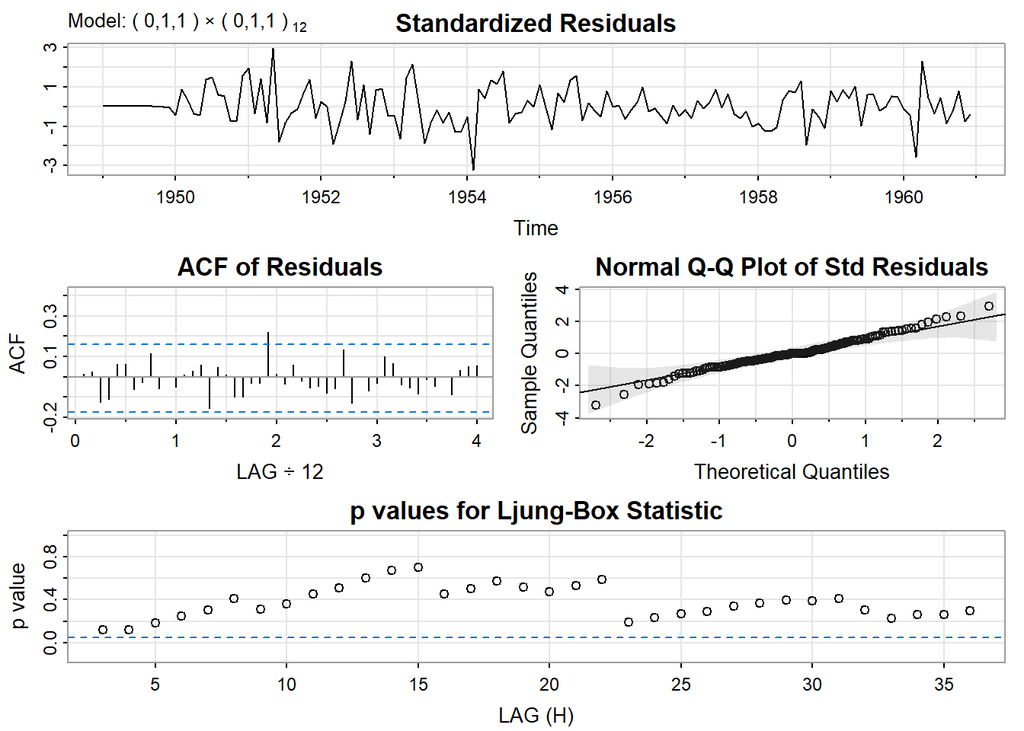

```r
library(astsa)
dane <- log(AirPassengers)

sarima <- sarima(dane, p=0,d=1,q=1, P=0, D=1, Q=1, S=12)
```

Nie jest widoczna istotna statystycznie autokorelacja reszt, a ich rozkład jest w przybliżeniu normalny. Wyznaczamy prognozę poza próbą.

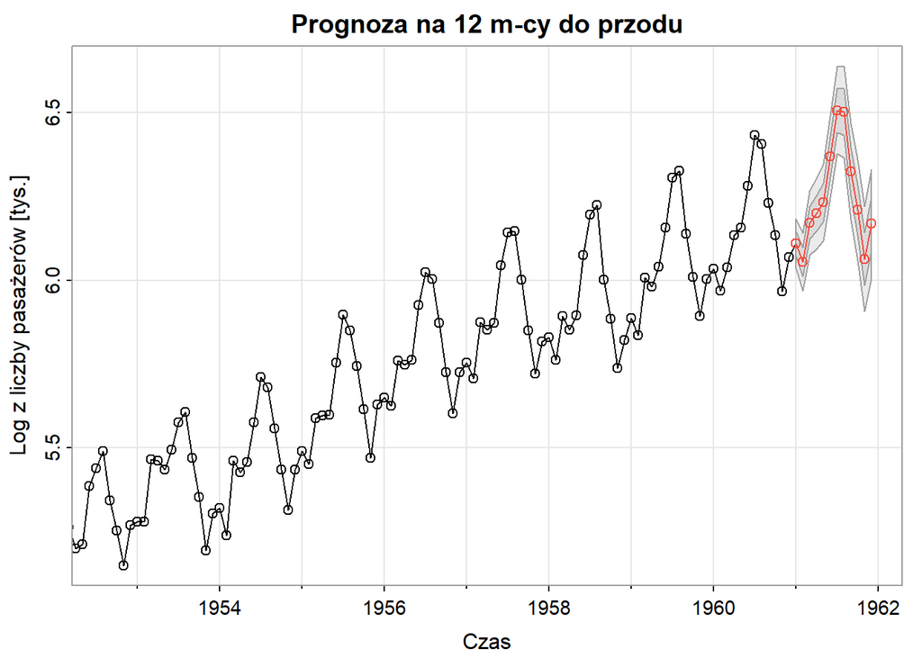

```
## $pred
##           Jan      Feb      Mar      Apr      May      Jun      Jul      Aug
## 1961 6.110186 6.053775 6.171715 6.199300 6.232556 6.368779 6.507294 6.502906
##           Sep      Oct      Nov      Dec
## 1961 6.324698 6.209008 6.063487 6.168025
##
## $se
##             Jan        Feb        Mar        Apr        May        Jun
## 1961 0.03671562 0.04278291 0.04809072 0.05286830 0.05724856 0.06131670
##             Jul        Aug        Sep        Oct        Nov        Dec
## 1961 0.06513124 0.06873441 0.07215787 0.07542612 0.07855851 0.08157070
```

```r
sarima.for(dane, n.ahead = 12,  p=0,d=1,q=1, P=0, D=1, Q=1, S=12, main = "Prognoza na 12 m-cy do przodu", ylab = "Log z liczby pasażerów [tys.]", xlab = "Czas")
```

Przechodzimy do szkicowania periodogramów i wykresów funkcji przenoszenia mocy.

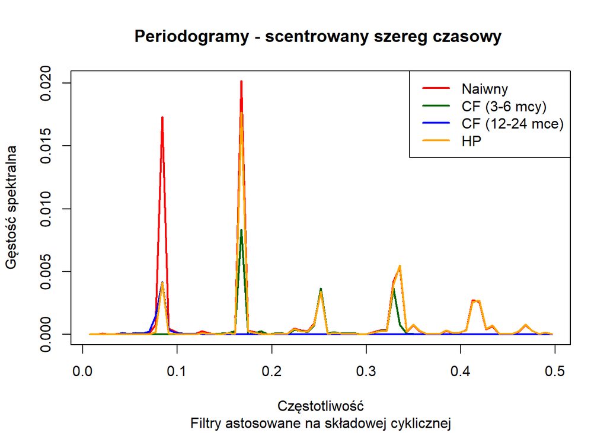

```r
# różnicowanie danych
dane_ts <- diff(dane)

# filtr CF - periodogram dla składowej cyklicznej
# pl=1, pu=6 oznacza pasmo od 3 do 6 miesięcy
cf_short <- spec.pgram(cffilter(dane_ts, pl=3, pu=6)$cycle,
           detrend = F, pad=0, taper=0, demean = F, fast = F, plot=F)

# znów filtr CF, ale inne pasmo
# pl=12, pu=24 oznacza pasmo od 12 do 24 miesięcy
cf_long <- spec.pgram(cffilter(dane_ts, pl=12, pu=24)$cycle,
           detrend = F, pad=0, taper=0, demean = F, fast = F, plot=F)

# filtr HP
hp <- spec.pgram(hpfilter(dane_ts, freq = 12,
        type="frequency")$cycle, detrend = F,
        pad=0, taper=0, demean = F, fast = F, plot=F)

# periodogram naiwny
oryg <- spec.pgram(dane_ts, detrend = F,
                   pad=0, taper=0,
                   demean = F, fast = F, plot = F)

# Pierwszy wykres - periodogramy
plot(oryg$freq/12, oryg$spec, col = "red", type = "l",
     main = "Periodogramy - scentrowany szereg czasowy ",
     sub = "Filtry astosowane na składowej cyklicznej",
     ylab = "Gęstość spektralna", xlab = "Częstotliwość", lwd=2)
lines(cf_short$freq/12, cf_short$spec, col = "darkgreen", lwd=2)
lines(cf_long$freq/12, cf_long$spec, col = "blue", lwd=2)
lines(hp$freq/12, hp$spec, col = "orange", lwd=2)

legend("topright",
       legend = c("Naiwny","CF (3-6 mcy)", "CF (12-24 mce)",  "HP"),
       col = c("red", "darkgreen", "blue", "orange"),
       lty = 1, lwd = 2)
```

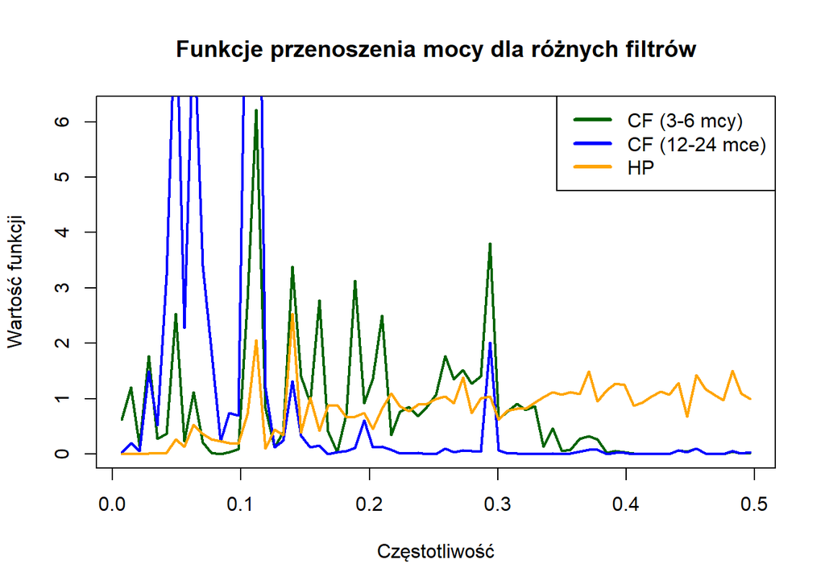

```r
# wyznaczamy funkcję przenoszenia mocy
transfer_fun <- function(pgram_oryg, pgram2) {pgram2$spec / pgram_oryg$spec}

plot(oryg$freq/12, transfer_fun(oryg, cf_short), type = "l", col ="darkgreen", lwd=2,
     main = "Funkcje przenoszenia mocy dla różnych filtrów",
     ylab = "Wartość funkcji", xlab = "Częstotliwość")
lines(oryg$freq/12, transfer_fun(oryg, cf_long), col = "blue", lwd=2)
lines(oryg$freq/12, transfer_fun(oryg, hp), col = "orange", lwd=2)

legend("topright",
       legend = c("CF (3-6 mcy)", "CF (12-24 mce)", "HP"),
       col = c("darkgreen", "blue", "orange"),
       lty = 1, lwd = 3)
```

Periodogram naiwny (czerwony) sugeruje występowanie cyklu rocznego ($f\approx0,083$) i półrocznego ($f\approx0,16$). Jeden z filtrów Christiano- Fitzgeralda (niebieski, ale linia jest słabo widoczna, przykryta przez inne…) przepuścił częstotliwość odpowiadającą cyklowi rocznemu, a drugi z nich (zielony) przepuścił częstotliwość odpowiadającą cyklowi półrocznemu. Cykl kwartalny ($f\approx0,32$) także został wyłapany, ale jest mniej wyraźny.

Analizując funkcję przenoszenia mocy, stwierdzamy, że filtry wzmacniają bardzo mocno niskie częstotliwości. To zjawisko jst niepożądane, oczekiwalibyśmy wytłumienia niektórych składowych, ale nie ich kilkukrotnego wzmocnienia. Nie jestem pewny, czy tak wyglądająca f. przenoszenia mocy to wynik błędu w kodzie. Jeśliby jednak przyjąć, że nie, to niebieski filtr CF tłumi wysokie częstotliwości ($>\approx 0,3$).

Teraz, wykorzystując `kernapply`, pozbywamy się cyklu rocznego.

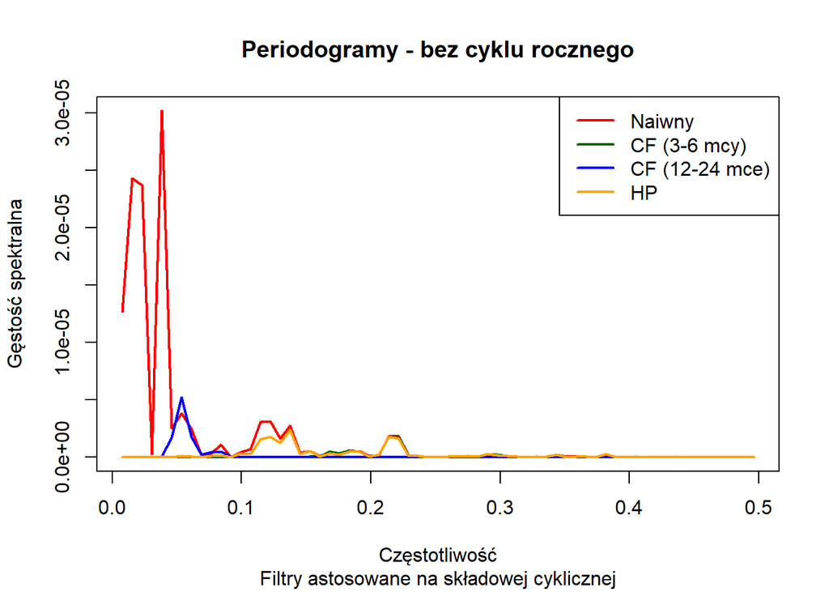

```r
# Parametr 6 oznacza, że bierzemy pod uwagę 6 obserwacji wstecz i w przód (łącznie okno o szerokości ok. roku)
k = kernel("modified.daniell", 6)

# 2. Wygładzenie szeregu
dane_smoothed <- kernapply(dane_ts, k)

# filtr CF - periodogram dla składowej cyklicznej
# pl=1, pu=6 oznacza pasmo od 3 do 6 miesięcy
cf_short <- spec.pgram(cffilter(dane_smoothed, pl=3, pu=6)$cycle,
           detrend = F, pad=0, taper=0, demean = F, fast = F, plot=F)

# znów filtr CF, ale inne pasmo
# pl=12, pu=24 oznacza pasmo od 12 do 24 miesięcy
cf_long <- spec.pgram(cffilter(dane_smoothed, pl=12, pu=24)$cycle,
           detrend = F, pad=0, taper=0, demean = F, fast = F, plot=F)

# filtr HP
hp <- spec.pgram(hpfilter(dane_smoothed, freq = 12,
        type="frequency")$cycle, detrend = F,
        pad=0, taper=0, demean = F, fast = F, plot=F)

# periodogram naiwny
oryg <- spec.pgram(dane_smoothed, detrend = F,
                   pad=0, taper=0,
                   demean = F, fast = F, plot = F)

plot(oryg$freq/12, oryg$spec, col = "red", type = "l",
     main = "Periodogramy - bez cyklu rocznego",
     sub = "Filtry astosowane na składowej cyklicznej",
     ylab = "Gęstość spektralna", xlab = "Częstotliwość", lwd=2)
lines(cf_short$freq/12, cf_short$spec, col = "darkgreen", lwd=2)
lines(cf_long$freq/12, cf_long$spec, col = "blue", lwd=2)
lines(hp$freq/12, hp$spec, col = "orange", lwd=2)

legend("topright",
       legend = c("Naiwny","CF (3-6 mcy)", "CF (12-24 mce)",  "HP"),
       col = c("red", "darkgreen", "blue", "orange"),
       lty = 1, lwd = 2)
```

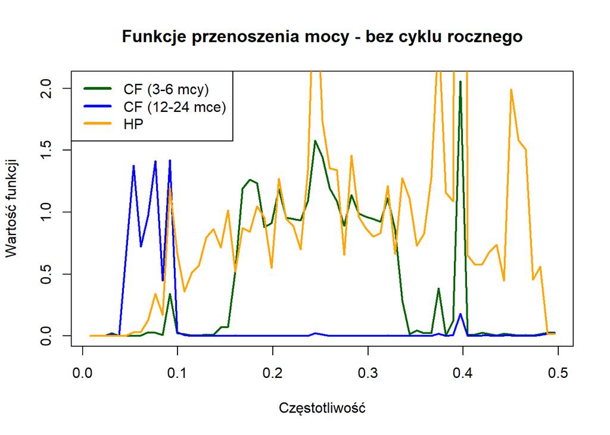

```r
# wyznaczamy funkcję przenoszenia mocy
transfer_fun <- function(pgram_oryg, pgram2) {pgram2$spec / pgram_oryg$spec}

plot(oryg$freq/12, transfer_fun(oryg, cf_short), type = "l", col ="darkgreen", lwd=2,
     main = "Funkcje przenoszenia mocy - bez cyklu rocznego",
     ylab = "Wartość funkcji", xlab = "Częstotliwość")
lines(oryg$freq/12, transfer_fun(oryg, cf_long), col = "blue", lwd=2)
lines(oryg$freq/12, transfer_fun(oryg, hp), col = "orange", lwd=2)

legend("topleft",
       legend = c("CF (3-6 mcy)", "CF (12-24 mce)", "HP"),
       col = c("darkgreen", "blue", "orange"),
       lty = 1, lwd = 3)
```

Po odfiltrowaniu częstotliwości rocznej obraz całkowicie się zmienia. Patrząc na skalę osi y, trudno jest wskazać jakiekolwiek cykle o okresie krótszym niż rok. Niebieski filtr CF blokuje częstotliwości wyższe ($>\approx0,1$), a zielony przepuszcza średnie częstotliwości. To oczywiście odpowiada temu, jak te filtry zostały zdefiniowane. Filtr Hodricka- Prescotta blokuje natomiast częstotliwości b. niskie. Zjawisko nadmiernego wzmacniania sygnału, obserwowane bardzo mocno wcześniej, wciąż występuje, ale jest ograniczone.

### Zadanie 4.7

Wczytujemy dane i szkicujemy periodogramy naiwne zwykłe oraz wygładzone oknem Daniella dla inflacji i bezrobocia.

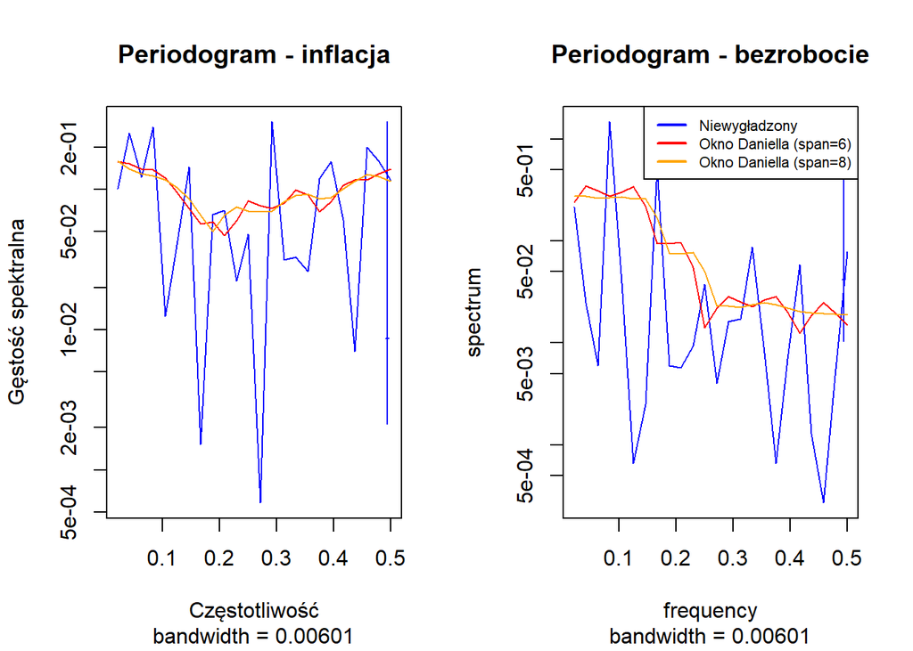

```r
dane <- read.csv("Dane/infl_bezr.csv", sep=";")
dane <- apply(dane, FUN = function(x) diff(x), MARGIN = 2)

dane_ts <- ts.intersect(dane)


t <- 1:floor(length(dane)/2) * 2*pi

par(mfrow = c(1,2))
spec.pgram(dane_ts[,1], pad=F, taper=0, detrend = F, main= "Periodogram - inflacja", col = "blue", ylab = "Gęstość spektralna", xlab = "Częstotliwość")

spec.pgram(dane_ts[,1], pad=F, taper=0, detrend = F, main= "Periodogram - inflacja", add=T, spans = 6, col = "red")

spec.pgram(dane_ts[,1], pad=F, taper=0, detrend = F, main= "Periodogram - inflacja", add=T, spans = 8, col = "orange")

spec.pgram(dane_ts[,2], pad=F, taper=0, detrend = F, main= "Periodogram - bezrobocie", col = "blue")

spec.pgram(dane_ts[,2], pad=F, taper=0, detrend = F, main= "Periodogram - bezrobocie", add=T, spans = 6, col = "red")

spec.pgram(dane_ts[,2], pad=F, taper=0, detrend = F, main= "Periodogram - bezrobocie", add=T, spans = 8, col = "orange")

legend("topright",
       legend = c("Niewygładzony",
                  "Okno Daniella (span=6)",
                  "Okno Daniella (span=8)"),
       col = c("blue", "red", "orange"),
       lty=1, lwd=2, cex = .7)
```

#### Koherencja

Przechodzimy do analizy koherencji. Możemy ją porównać do współczynnika korelacji, tyle że liczonego w nieco odmienny sposób:

$$C_{xy}(f) =
\frac{|P_{xy}(f)|^2}{P_{xx}(f)P_{yy}(f)}$$
A zatem, koherencja to iloraz kwadratu modułu gęstości wzajemnej do iloczynu gęstości widmowych obu szeregów czasowych. Analogicznie do wsp. korelacji, koherencja przyjmuje wartości z przedziału [0,1].

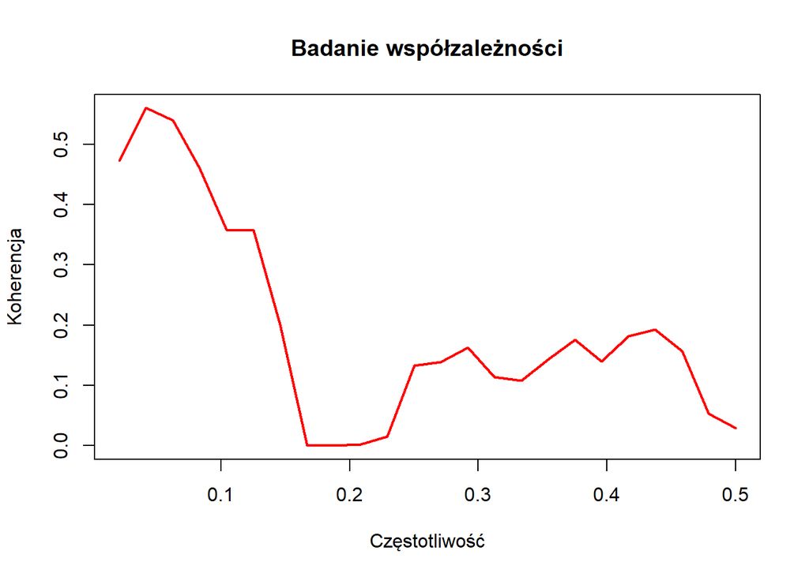

```r
pgram <- spec.pgram(dane_ts, spans=6, pad=F, taper=0, detrend=F, plot = F)

max_coh <- max(pgram$coh)
plot(pgram$freq, pgram$coh, type="l", main ="Badanie współzależności", ylab="Koherencja", xlab = "Częstotliwość", col = "red", lwd=2)
```

```r
cat("Maksymalna wartość koherencji to", max_coh, "co odpowiada", 1/pgram$freq[pgram$coh == max_coh], "miesiecznemu cyklowi.")
```

```
## Maksymalna wartość koherencji to 0.5603934 co odpowiada 24 miesiecznemu cyklowi.
```

Obserwowany pik na wykresie koherencji oznacza, że oba szeregi czasowe (inflacji i bezrobocia) mają wspólny, 2-letni okres.

#### Opóźnienie fazowe

Koherencja mówi nam, czy szeregi czasowe mają okres o tej samej (zbliżonej) częstotliwości, ale nie odpowiada na pytanie, czy jeden z nich jest względem drugiego opóżniony. Tutaj pomaga opóźnienie fazowe.

```r
idx <- which.max(pgram$coh)
phi <- pgram$phase[idx]
omega <- pgram$freq[idx]
tau <- phi / omega / (2*pi)
tau
```

```
## [1] 11.23383
```

Wynik sugerowałby, że inflacja reaguje z opóźnieniem około prawie rocznym w stosunku do bezrobocia. Na zajęciach doszliśmy jednak do innego wyniku (opóźnienie 1.5 m-ca)…